# Think like a programmer - an introduction

Thursday 15, December

# Base Plotting

This is what you need to know about plotting:

> Plotting is always tricky but one thing is for sure: do not use pie-charts

For all the other best practices about plotting, [this is the website](https://www.data-to-viz.com/caveats.html) that you want to check out.

## A very basic scatterplot

Plotting in R doesn’t change much between the type of plot. Either a scatterplot, a lineplot, an histogram…once you get the idea of how it works, then it’s done (although, I still have to grasp this idea myself).

Let’s plot some data, then:

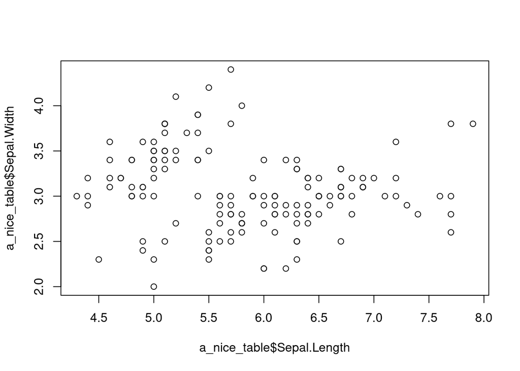

```r
# load a table from a csv file
a_nice_table <- read.csv("/home/gabriele/work/microbiology/think_like_a_programmer/R_foundations/lessons_files/data/a_nicely_formatted_table.csv", header=T, sep=",")

# let's use Sepal length and width to plot a simple scatterplot
plot(x=a_nice_table$Sepal.Length, y=a_nice_table$Sepal.Width)
```

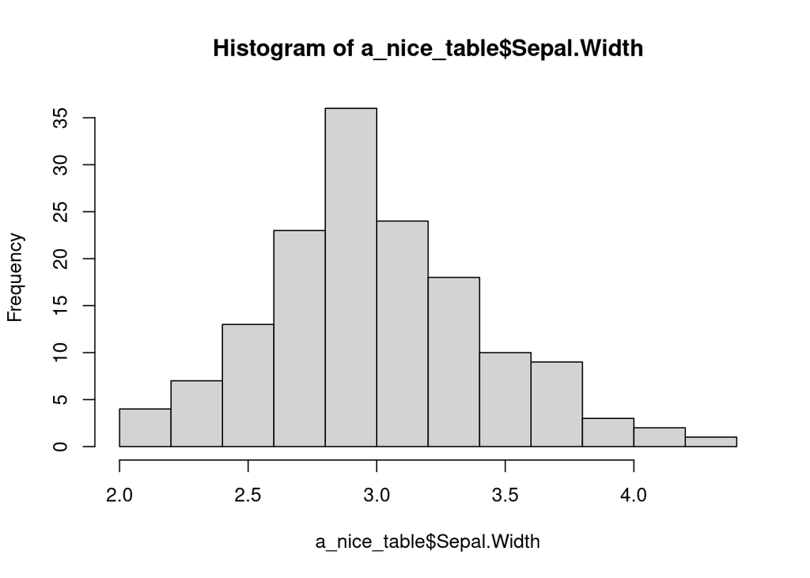

```r
# let's plot a histogram, now
hist(a_nice_table$Sepal.Width)
```

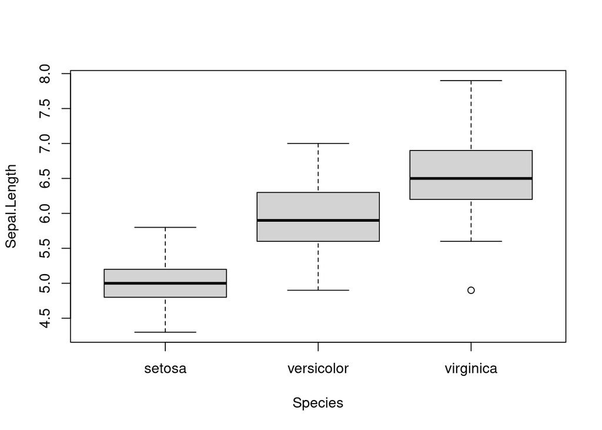

```r
# and a boxplot
boxplot(Sepal.Length ~ Species, data = a_nice_table)
```

Not bad, but you can do better. For instance, add some color, why not? Also, the axis labels don’t look very nice. What can you do?? Let’s look at what the R manual has to say regarding the `plot` function.

```r
help(plot)
```

Ok, but how to assign colours to data points? You may want to colour the data points with respect to the species they belong to.

To do it, you will need a colour for each species, i.e. each category. It’s now time to think like the programmer you are. Some questions you should ask yourself:

1. How do I get a set of colours?
2. How many colours do I need?
3. How do I even create a set of colours?
4. How big should this set be?

Let’s try to answer:

1. [R colours, here](http://www.stat.columbia.edu/~tzheng/files/Rcolor.pdf)
2. how about one color `for` each category/species?
3. what about a vector?
4. it’s definitely possible that I will need a colour for each data point, right?
5. or even a shape?? for shapes, see [here](https://www.rdocumentation.org/packages/graphics/versions/3.6.2/topics/points)

If you think these answers make sense…it’s time to worry about how to assign a colour to a category, i.e. how to actually make answer n. 3 a reality? Again, let’s think programming. What we know:

1. the number of data points;
2. the category of each data point, i.e. the species;
3. which colours to use;
4. a vector is needed and it must be as long as the number in `1.`;
5. in answer n. 2 (see above) there is a very specific keyword.

Side note: shape, for R are called **pch** (probable meaning of **pch** is *point character*). So if you want to know which shapes are available, now you have the keyword.

Always remember that, if you want to fill the points you see in the plot, you need to set the shape using one **pch** that allows you to have a *fill*.

Now, using the ideas above, plot:

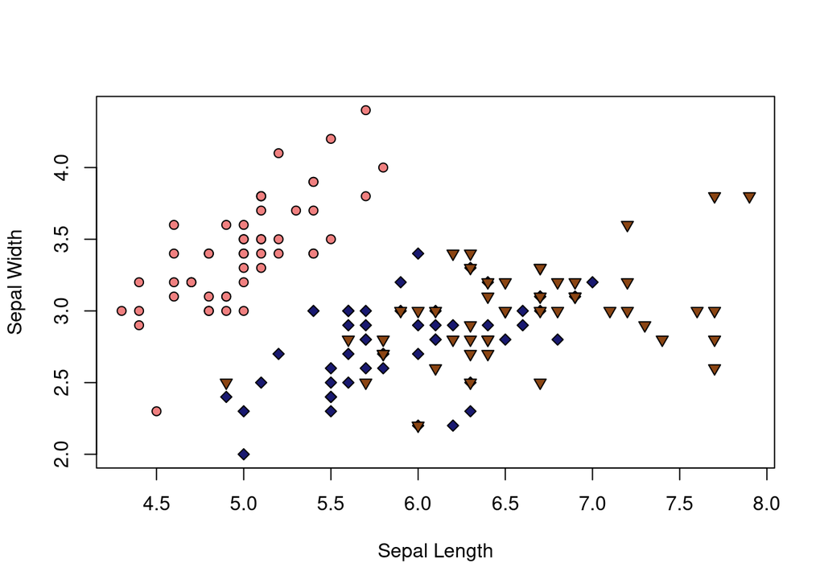

```r
# colours I like
colours_i_like <- c("lightcoral", "midnightblue", "saddlebrown")

# shapes I like
shapes_i_like <- c(21, 23, 25)

# empty vector with a colour for each data point
data_colours <- vector()

# empty vector with a different shape for each data point
data_shapes <- vector()

# for each category/species
for (sp in a_nice_table$Species) {
  # get its colour and shape
  if (sp=="setosa") {
    # assign colour
    data_colours <- append(data_colours, colours_i_like[1])
    # assign shape
    data_shapes <- append(data_shapes, shapes_i_like[1])
  } else if (sp=="versicolor") {
    # assign colour
    data_colours <- append(data_colours, colours_i_like[2])
    # assign shape
    data_shapes <- append(data_shapes, shapes_i_like[2])
  } else {
    # assign colour
    data_colours <- append(data_colours, colours_i_like[3])
    # assign shape
    data_shapes <- append(data_shapes, shapes_i_like[3])
  }
}

# have a look at data colours and shapes
data_colours
data_shapes

# use data_colours to color the data points
plot(x=a_nice_table$Sepal.Length, y=a_nice_table$Sepal.Width, pch=data_shapes, bg=data_colours, col="black", xlab="Sepal Length", ylab="Sepal Width")
```

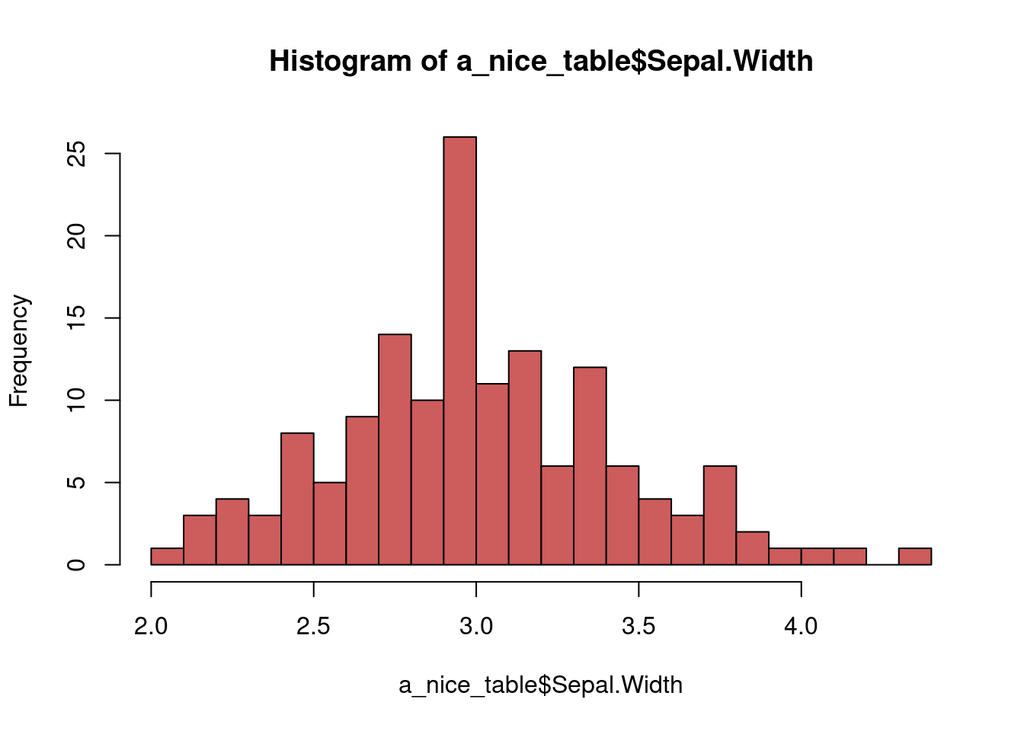

```r
# or we can modify the histogram
hist(a_nice_table$Sepal.Width, col="indianred", breaks=20)
```

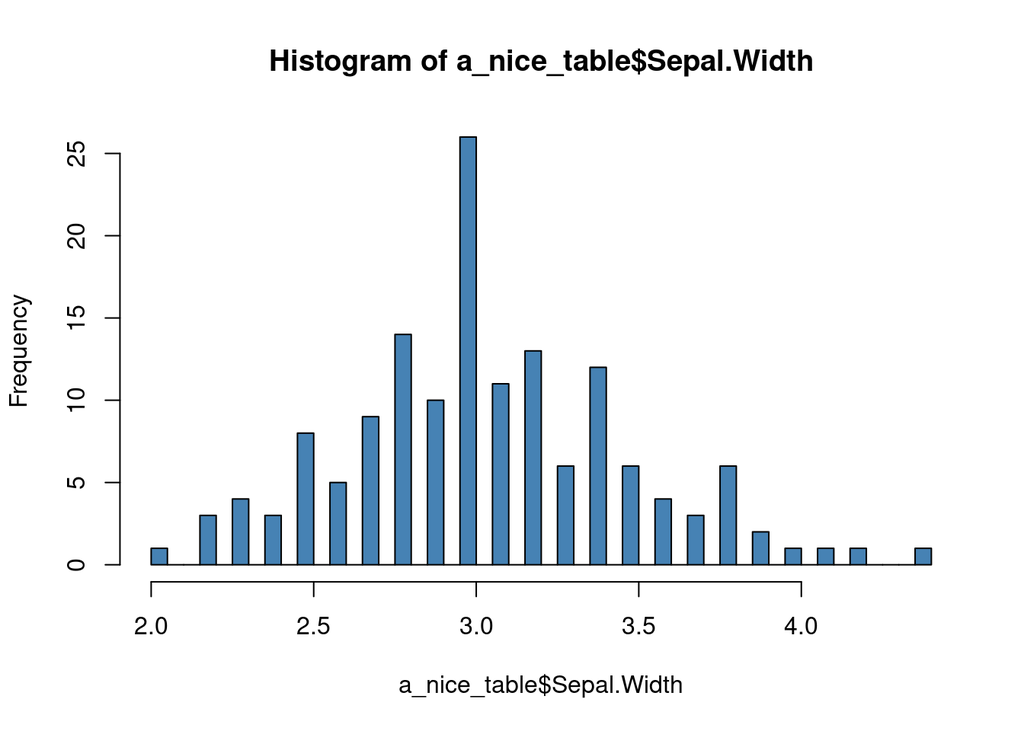

```r
hist(a_nice_table$Sepal.Width, col="steelblue", breaks=50)
```

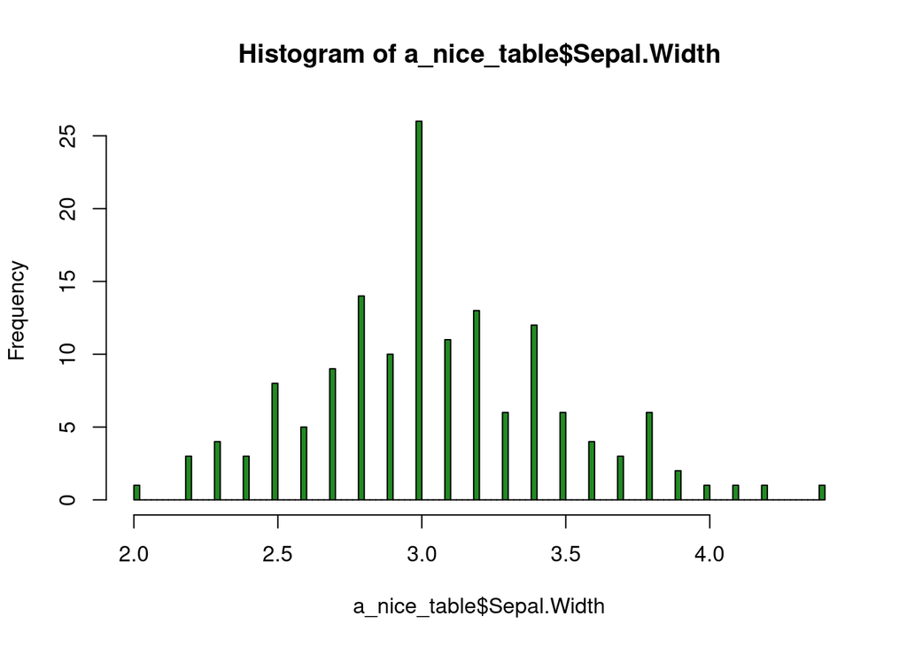

```r
hist(a_nice_table$Sepal.Width, col="forestgreen", breaks=100)
```

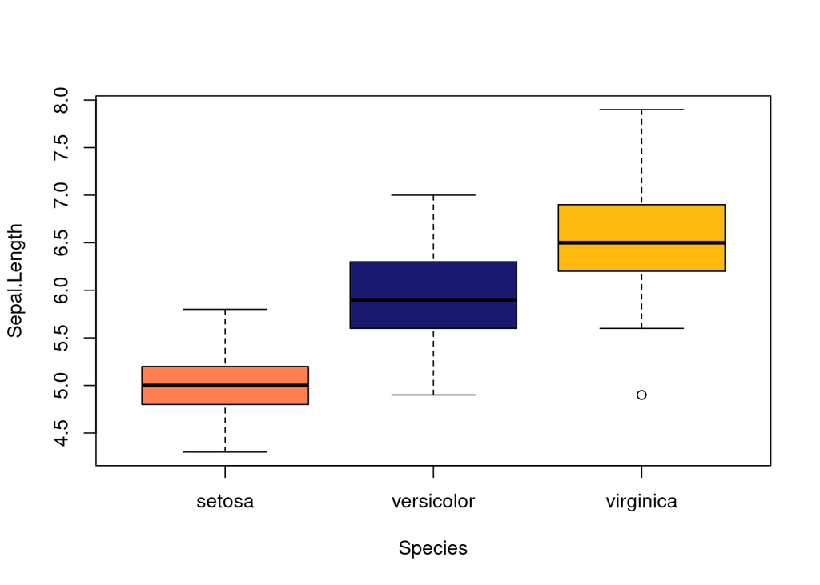

```r
# or add colour to the boxplot
boxplot(Sepal.Length ~ Species, data = a_nice_table, col=c("coral", "midnightblue", "darkgoldenrod1"))
```

Oh, that is better. But wait…how do a person know which species is which? The legend is missing, so you need to add it. A legend is something that you add *on top* of the plot, it’s not included in the `plot()` function (no signs of a legend in the `help(plot)` right?). Let’s have a look at `help(legend)`.

[figure not shown]

```r
# scatterplot with colours
plot(x=a_nice_table$Sepal.Length, y=a_nice_table$Sepal.Width, pch=data_shapes, bg=data_colours, col="black", xlab="Sepal Length", ylab="Sepal Width")

# add a legend, and that's it!
legend("bottomright", c("setosa","virginica", "versicolor"), col=colours_i_like, pch=shapes_i_like)
```